# The composition and weathering of the continents over geologic time

Alex Lipp

13/07/2020

This document performs the data preprocessing and analysis for the article *‘The composition and weathering of the continents over geologic time’*.

# Setup

Firstly we load in the required libraries. If these packages are not already installed they can be installed using the `install_packages` function. Note that the `deeptime` package may have to be installed manually.

```r
library(ggplot2)
library(directlabels)
library(reshape2)
library(MASS)
library(ggridges)
library(dplyr)
library(deeptime)
```

Now we define some auxilliary functions that are helpful for compositional data analysis.

```r
clr_trsfm <- function(df){
  # Performs centred log ratio transformation on a compositional dataframe
  out<-data.frame(t(apply(df,1,function(x) log(x/exp(sum(log(x)/length(x)))))))
  rownames(out) <- rownames(df)
  return(out)
}
clr_inv <- function(df){
  # Performs the inverse of the centred log ratio transformation on CLR dataframe.
  # NB this returns the composition normalised to 1
  out<-data.frame(t(apply(df,1,function(x) exp(x)/(sum(exp(x))))))
  return(out)
}
close <- function(df){
  # Normalises compositional data to 1
  out<-data.frame(t(apply(df,1,function(x) x/(sum(x)))))
  rownames(out) <- rownames(df)
  return(out)
}
norm_vec <- function(x){
  # Returns the norm (magnitude) of a vector
  return(sqrt(sum(x^2)))
}

# Weathering and provenance vectors used in this analysis

w_vec_consensus <- c(0.2418534,  0.3691629,  0.2349810,
                     0.1338786, -0.4874057, -0.6782411,  0.1857709) # Average of Tooronogo and White 2001.
p_vector_original <- c( 0.23373465,  0.09797867,
                        -0.23159232, -0.60061708, +
            0.24779572, -0.33628409,  0.58898446)

UCC_clr_rudnickgao <- c(2.333699,   0.8690621,  -0.1423602,
                        -0.9570468, +
                 -0.6805154,    -0.5871532, -0.835686)


coefficients_to_comp <- function(omega,psi){
  # Calculates compositions from omega/psi coefficients (requires w, p and UCC predefined)
  w <- w_vec_consensus
  p <- p_vector_original
  UCC_clr <- UCC_clr_rudnickgao
  clr = t(data.frame(UCC_clr + omega*w + psi*p))
  rownames(clr) <- NULL
  out <- clr_inv(clr)
  names(out) <- oxides_list
  return(out)
}
```

# Loading and preprocessing geochemical data

We load in the data from the [Sedimentary Geochemistry and Paleoenvironments Project](https://sgp.stanford.edu/).

```r
data_raw <- read.csv("data/SGP_final.csv", na.strings = "NULL")
# In the 'interpreted_age' column NULL is used as an na string so we flag
# that here.
```

## Convert to oxides

Alongside a host of meta data we are given the chemical composition in wt% elemental form, but we need it in wt% oxides, so we convert using [the factors here](https://www.jcu.edu.au/advanced-analytical-centre/services-and-resources/resources-and-extras/element-to-stoichiometric-oxide-conversion-factors). We also put them in the order Si, Al, Fe, Mg, Na, Ca, K and normalise so that each composition sums to the same total value, 1. We also exclude `NA` samples.

```r
# Convert elemental to oxide
data_raw$SiO2 <- data_raw$si_wtpct * 2.1392
data_raw$Al2O3 <- data_raw$al_wtpct * 1.8895
data_raw$Fe2O3 <- data_raw$fe_wtpct * 1.4297
data_raw$MgO <- data_raw$mg_wtpct * 1.6582
data_raw$Na2O <- data_raw$na_wtpct * 1.3480
data_raw$CaO <- data_raw$ca_wtpct * 1.3992
data_raw$K2O <- data_raw$k_wtpct * 1.2046

# This allows quick indexing of the important part of the data
oxides_list <- c("SiO2","Al2O3","Fe2O3","MgO","Na2O","CaO","K2O")

# Close dataset
data_raw[,oxides_list] <- close(data_raw[,oxides_list]) # Close dataset
data_raw <- data_raw[!(is.na(data_raw$sample_id)),] # Screen out NA samples

unique(data_raw$lith_name)
```

```
##  [1] carbonate             shale                 phosphorite
##  [4] ore                   mudstone              siltstone
##  [7] lime mudstone         <NA>                  chert
## [10] sandstone             iron formation        limestone
## [13] dolomudstone          conglomerate          dolomite
## [16] wackestone            sand                  quartzite
## [19] limestone/dolomite    breccia               oil shale
## [22] arkose                tuff                  argillite
## [25] bentonite             ash                   mud
## [28] hornfels              arenite               concretion
## [31] jasperoid             spiculite             volcaniclastic undet.
## [34] diatomite             meta-argillite        slate
## [37] tonstein              gypsum                anhydrite
## [40] greywacke             metagreywacke         pelite
## [43] metapelite            claystone             metasiltstone
## [46] grainstone            porcellanite          boundstone
## [49] packstone             marl                  crystalline limestone
## 50 Levels: anhydrite arenite argillite arkose ash bentonite ... wackestone
```

## Screen out lithologies

```r
data_raw <- data_raw[data_raw$lith_name %in% c("shale", "mudstone", "siltstone", "sandstone", "sand","arkose", "arenite",
                              "oil shale", "argillite", "mud", "meta-argillite", "slate", "greywacke",
                              "metagreywacke", "pelite", "metapelite", "claystone", "metasiltstone"),] # Screen out NA samples
nrow(data_raw)
```

```
## [1] 17852
```

## Merge in previous compilation

We’re now going to merge in the data from our [previous paper](https://agupubs.onlinelibrary.wiley.com/doi/full/10.1029/2019GC008758) as this has more samples in the Archean. There are some samples in this previous compilation that are also present in the SGP dataset. The duplicates were manually identified and are removed from consideration here.

```r
data_prev_paper_raw <- read.csv("data/sedimentary_rocks_PCA_paper.csv")
data_prev_paper_raw[,oxides_list] <- close(data_prev_paper_raw[,oxides_list]) # Close to 1
data_prev_paper_raw <- data_prev_paper_raw[!data_prev_paper_raw$Age.in.SGP.=="Y",] # Remove duplicate samples

data_raw$origin <- "SGP"
data_prev_paper_raw$origin <- "Personal Compilation"

data_raw <- bind_rows(data_raw,data_prev_paper_raw)
```

## Remove samples with zeros

Compositional data analysis can’t cope with BDL values reported as “0”, so we explicitly remove these. This only removes 24 samples.

```r
data_raw_no_zeros <- data_raw[!(apply((data_raw[,oxides_list] == 0),1,function(x) any(x))),]
any(data_raw_no_zeros[,oxides_list] == 0) # Should be false if 0's all removed
```

```
## [1] FALSE
```

```r
nrow(data_raw_no_zeros) - nrow(data_raw) # Number of samples removed
```

```
## [1] -24
```

## Remove those with possible carbonate

This KDE plot shows that there are a considerable number of samples with high values of CaO. These are highly likely to contain calcium carbonate which is not accounted for in the model and should be removed.

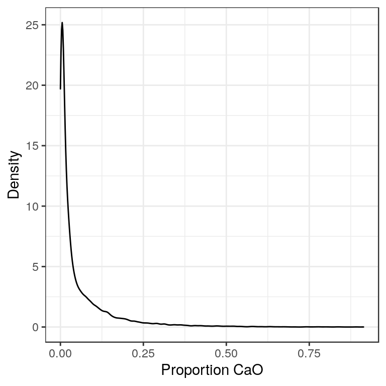

It is specifically difficult to disentangle the effects of calcium addition from carbonate contamination from calcium addition from cation exchange with sodium, a problem resolved later. To exclude these samples we need to define the maximum amount of calcium we expect to see in a normal sediment which is unaffected by carbonate addition. A conservative estimate for the maximum amount of calcium a sediment can have would be the sum of the raw amount of calcium with the amount that could be added by swapping all the sodium out in the correct stoichometry. (A useful recent paper on cation exhchange by Maaren Lupker can be found [here](https://esurf.copernicus.org/articles/4/675/2016/)). This makes the assumption that all of the sodium in a sediment is exchangeable and thus this is a conservative estimate. We calculate this threshold using igneous rocks as these represent the geological materials and possible sediment protoliths with the highest total amount of Ca and Na (as weathering strips Na and Ca from rocks. Thus we look for the total natural amount of exchangeable Na and Ca in a sediment. This is given as the maximum possible amount of Ca, in moles, the sample could have, per kg of major element oxides.

The function defined below returns the possible number of moles of Ca per kg of sample, assuming all the Na is exchanged.

```r
poss_max_ca <- function(composition){
  raw_cao = composition["CaO"] # wt% ox
  raw_ca = raw_cao / 1.3992
  raw_ca_moles = raw_ca / 40.078
  raw_na2o = composition["Na2O"] # wt% ox
  raw_na = raw_na2o/1.3480 # wt% elem
  raw_na_moles = raw_na/22.989 # moles sodium
  xchngbl_ca_moles = 0.5 * raw_na_moles # sodium exchanges with calcium in ratio 2:1
  tot_ca_moles = raw_ca_moles + xchngbl_ca_moles # total possible amount of calcium
  return(tot_ca_moles)
}
example_composition <- (data_raw_no_zeros[100,oxides_list])
example_composition
```

|  | SiO2 | Al2O3 | Fe2O3 | MgO | Na2O | CaO | K2O |
| --- | --- | --- | --- | --- | --- | --- | --- |
| 102 | 0.7803768 | 0.1179239 | 0.02998669 | 0.01589965 | 0.00928435 | 0.01536782 | 0.03116077 |

```r
poss_max_ca(example_composition)
```

|  | CaO |
| --- | --- |
| 102 | 0.0004238477 |

How do we find out the threshold value for number of moles of Ca above which we know carbonate must be added? We apply this function to a suite of igneous rocks and take the maximum value. The suite of igneous rocks we use is from the Crater Lake suite and covers the full range of igneous rock compositions from Basaltic to Rhyolitic (see [Lipp et al. 2020](https://agupubs.onlinelibrary.wiley.com/doi/full/10.1029/2019GC008758)). This then is the largest possible number of moles of Ca you can possible expect to find in a sediment. Anything more than this requires addition of CaCO3. The igneous suite we use is that from Crater Lake.

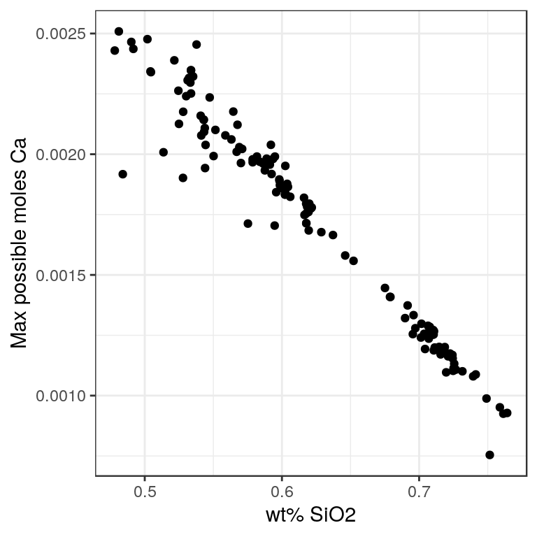

```r
igneous_rocks <- close(read.csv("data/craterlake_igneous.csv")[,5:11]) # Load in data and close it to 1
maximum_poss_ca = apply(igneous_rocks,1,poss_max_ca) # Find max poss ca for all igneous rocks


ggplot(igneous_rocks,aes(x=SiO2,y=maximum_poss_ca)) + geom_point() + theme_bw() +
  xlab("wt% SiO2") + ylab("Max possible moles Ca")
```

```r
max_poss_ca  = max(apply(igneous_rocks,1,poss_max_ca))
max_poss_ca
```

```
## [1] 0.002508786
```

Thus the largest amount of Ca we can expect to observe in 1 kg of sample that is unaffected by carbonate addition is $2.5 \times 10^{-3} \ \mathrm{mol}$. We also observe that basalts (i.e., low SiO2 samples) are those with the highest amount of possible moles Ca.

Thus now we filter the dataset to remove any samples which have a possible amount of Ca that exceeds this value.

```r
maximum_poss_ca_sgp = apply(data_raw_no_zeros[,oxides_list],1,poss_max_ca)

sum(maximum_poss_ca_sgp > 0.002508786)
```

```
## [1] 2972
```

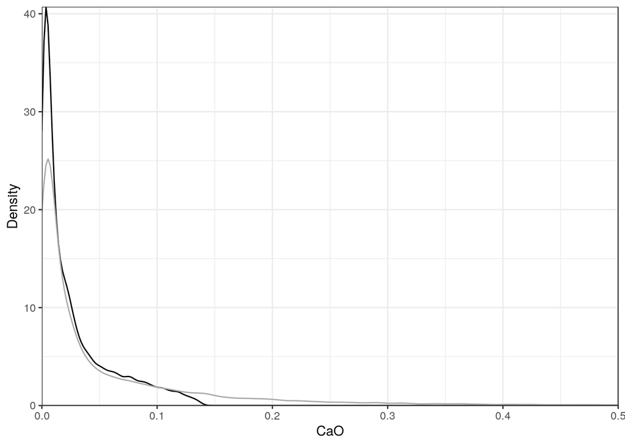

```r
data_cleaned = data_raw_no_zeros[(maximum_poss_ca_sgp < 0.002508786),]

ggplot(data_cleaned,aes(x=CaO)) + geom_density() + ylab("Density") + theme_bw() +
  geom_density(data=data_raw,aes(x=CaO),colour="darkgrey") +
  coord_cartesian(xlim=c(0,0.5),expand = c(0,0))
```

The above density plot shows that our filtered distribution of CaO (black) now has a tighter distribution, less likely to include carbonate contaminated samples (original distribution shown in grey).

# Data Analysis

## Numerically calculating $\omega$, $\psi$ and $\gamma$ for SGP dataset

Now we are ready to numerically calculated $\omega$, $\psi$ and degree of cation exchange (herein, $\gamma$ is used instead of `prop_ca` for cation exchange.) First we write down the three subsets to file so they can be accessed by the `python` inversion script. The inversion is numerical, and thus could be quite slow. `python` has a faster set of optimisation algorithms than `R`, and so the actual inversion is implemented in `python`. See the file `invert_coeffs_grad.py` for details.

```r
write.csv(data_cleaned[,oxides_list],"data/SGP_data_cleaned_comps.csv",row.names = F) # Write these to file so it can be accessed from python
```

Next we call the `python` inversion script, directing it to the data, as well as providing filenames for where we want `python` to write the output (the coefficients and the fitted compositions.)

```r
system("python invert_coeffs_grad.py data/SGP_data_cleaned_comps.csv data/SGP_data_cleaned_coeffs.csv data/SGP_data_cleaned_fit.csv")
# The 'system' function simply passes the string to the terminal. If this doesn't work, simply copy paste it into the terminal and run it from there.
```

This inversion being performed we load in the results and append them to the metadata files

```r
data_cleaned_coeffs <- read.csv("data/SGP_data_cleaned_coeffs.csv",header=F,col.names =c("omega","psi","catex"))
data_cleaned_fit <- read.csv("data/SGP_data_cleaned_fit.csv",header=F,col.names = oxides_list)
recombined_data <- cbind(data_cleaned,data_cleaned_coeffs) # This is our recombined dataframe of metadata and the calculated coefficients
```

## Generating and analysing composite samples over long timescales

To calculate changing weathering and provenance on long, Ga, timescales, we first need to split the dataset into subsets by age period.

```r
# Extract different time periods

modern <-  (recombined_data[recombined_data$interpreted_age < 500,]) # < 500
neo_prot <- (recombined_data[(recombined_data$interpreted_age < 1000) & (recombined_data$interpreted_age >= 500),]) # 500 -> 1000
meso_prot <- (recombined_data[(recombined_data$interpreted_age < 1500) & (recombined_data$interpreted_age >= 1000),]) # 1000 -> 1500
paleo_prot <- (recombined_data[(recombined_data$interpreted_age < 2000) & (recombined_data$interpreted_age >= 1500),]) # 1500 -> 2000
early_prot <- (recombined_data[(recombined_data$interpreted_age < 2500) & (recombined_data$interpreted_age >= 2000),]) # 2000 -> 2500
archean <- (recombined_data[(recombined_data$interpreted_age >= 2500),]) # > 2500

# Finer resolution in Archean
paleo_archean <- (recombined_data[(recombined_data$interpreted_age < 3000) & (recombined_data$interpreted_age >= 2500),]) # 2500 -> 3000
neo_archean <- (recombined_data[(recombined_data$interpreted_age < 3500) & (recombined_data$interpreted_age >= 3000),]) # 3000 -> 3500
hadean <-  (recombined_data[(recombined_data$interpreted_age >= 3500),]) # > 3500
```

Secondly we generate a ‘mixture’ of each time period. This represents the composition of the characteristic sediment coming off the continents at each time period. This mixing is done by calculating the arithmetic mean. Subsequently we calculate the $\omega, \psi$ values of these mixtures. Assuming the sedimentary record is passively sampled, these mixtures represent flux weighted means of the sediment coming off the continents during each time period.

```r
modern_mixture <- apply(modern[,oxides_list],2,function(x) mean(x,na.rm=T))
neo_prot_mixture <- apply(neo_prot[,oxides_list],2,function(x) mean(x,na.rm=T))
meso_prot_mixture <- apply(meso_prot[,oxides_list],2,function(x) mean(x,na.rm=T))
paleo_prot_mixture <- apply(paleo_prot[,oxides_list],2,function(x) mean(x,na.rm=T))
early_prot_mixture <- apply(early_prot[,oxides_list],2,function(x) mean(x,na.rm=T))
archean_mixture <- apply(archean[,oxides_list],2,function(x) mean(x,na.rm=T))

mixture_comps <- (rbind(modern_mixture,neo_prot_mixture,meso_prot_mixture,
                               paleo_prot_mixture,early_prot_mixture,archean_mixture))
print(mixture_comps)
```

```
##                         SiO2     Al2O3      Fe2O3        MgO       Na2O
## modern_mixture     0.7165072 0.1368183 0.05124564 0.02351230 0.01140904
## neo_prot_mixture   0.6996290 0.1562110 0.05424210 0.02177068 0.01257203
## meso_prot_mixture  0.6840140 0.1635742 0.05969057 0.02338081 0.01321864
## paleo_prot_mixture 0.6660089 0.1708600 0.05999510 0.02506784 0.01094366
## early_prot_mixture 0.6602221 0.1755102 0.07455420 0.02405862 0.01856376
## archean_mixture    0.6506850 0.1702858 0.07702773 0.03288459 0.02075977
##                           CaO        K2O
## modern_mixture     0.02990770 0.03059986
## neo_prot_mixture   0.01787719 0.03769807
## meso_prot_mixture  0.01533572 0.04078607
## paleo_prot_mixture 0.02130125 0.04582326
## early_prot_mixture 0.01253615 0.03455499
## archean_mixture    0.01836910 0.02998796
```

```r
write.csv(mixture_comps,"data/mixture_comps.csv",row.names = F)
```

Now we run the inversion on these mixtures…

```r
system("python invert_coeffs_grad.py data/mixture_comps.csv data/mixture_coeffs.csv data/mixture_fit.csv")
```

… and load in the results

```r
mixture_coeffs <- read.csv("data/mixture_coeffs.csv",header=F,col.names =c("omega","psi","catex"))
mixture_fit <- read.csv("data/mixture_fit.csv",header=F,col.names = oxides_list)
mixture_coeffs$origin <- c("modern","neo_prot","meso_prot","paleo_prot","early_prot","archean")
```

# Provenance Results

## Reconstructing average UCC composition

We can try and calculate the average composition of the crust over time using our mixture coefficients. Before doing this we have to calcualte the “pristine” $\omega$ value of igneous rocks. The value in the previous paper was calculated using a different *w* vector and model so its important to recalculate this.

```r
navdat <- read.csv("data/NAVDAT.csv")
navdat_cleaned <- navdat[!(apply(navdat[,oxides_list]==0,1,any)),] # Screen for 0s
any(navdat_cleaned[,oxides_list]==0) # No 0 values (should be false)
```

```
## [1] FALSE
```

```r
any(is.na(navdat_cleaned)) # No NAs (should be false)
```

```
## [1] FALSE
```

```r
# Calculate and extract coefficients
write.csv(navdat_cleaned[,oxides_list],"data/navdat_comps.csv",row.names = F) # Write these to file so it can be accessed from python
```

Now we calculate the coefficients…

```r
system("python invert_coeffs_grad.py data/navdat_comps.csv data/navdat_coeffs.csv data/navdat_fit.csv")
```

… and load in the results.

```r
navdat_coeffs <- read.csv("data/navdat_coeffs.csv",header=F,col.names =c("omega","psi","catex"))
navdat_fit <- read.csv("data/navdat_fit.csv",header=F,col.names =oxides_list)
navdat_resids <- clr_trsfm(navdat_cleaned[,oxides_list]) - clr_trsfm(navdat_fit) # Navdat residuals

navdat_cleaned$omega <- navdat_coeffs$omega
navdat_cleaned$psi <- navdat_coeffs$psi
navdat_cleaned$catex <- navdat_coeffs$catex

# Screen out anomalous samples
navdat_nohel <- navdat_cleaned[!(navdat_cleaned$Georef == "1995-068533"),] # Remove anomalous studies (see Lipp et al. 2020 for details)
navdat_nohel_noog<- navdat_nohel[!(navdat_nohel$Georef == "1980-042937"),]
navdat_residus_nohel <-  navdat_resids[!(navdat_cleaned$Georef == "1995-068533"),]
navdat_resids_cleaned <-  navdat_residus_nohel[!(navdat_nohel$Georef == "1980-042937"),]

navdat_cleaned_anomalous <- navdat_nohel_noog[navdat_nohel_noog$omega<0.5 & navdat_nohel_noog$omega>-1, ]  # Remove outliers

pristine_omega<-mean(navdat_cleaned_anomalous$omega)
stan_dev <- sd(navdat_cleaned_anomalous$omega)
upper = pristine_omega + stan_dev
lower = pristine_omega - stan_dev

print(paste("Pristine omega = ",round(pristine_omega,3)))
```

```
## [1] "Pristine omega =  -0.271"
```

Thus our new pristine $\omega$ value is -0.271. Now we use this value to estimate the bulk composition of the crust at different points in the Earth’s history.

## Crustal compositions

```r
# Extract the psi values

modern_psi <- mixture_coeffs[mixture_coeffs$origin=="modern","psi"]
neo_prot_psi <- mixture_coeffs[mixture_coeffs$origin=="neo_prot","psi"]
meso_prot_psi <- mixture_coeffs[mixture_coeffs$origin=="meso_prot","psi"]
paleo_prot_psi <- mixture_coeffs[mixture_coeffs$origin=="paleo_prot","psi"]
early_prot_psi <- mixture_coeffs[mixture_coeffs$origin=="early_prot","psi"]
archean_psi <- mixture_coeffs[mixture_coeffs$origin=="archean","psi"]

# Convert into estimate of average composition

modern_crust <- coefficients_to_comp(pristine_omega,modern_psi)
neo_prot_crust <- coefficients_to_comp(pristine_omega,neo_prot_psi)
meso_prot_crust <- coefficients_to_comp(pristine_omega,meso_prot_psi)
paleo_prot_crust <- coefficients_to_comp(pristine_omega,paleo_prot_psi)
early_prot_crust <-  coefficients_to_comp(pristine_omega,early_prot_psi)
archean_crust <- coefficients_to_comp(pristine_omega,archean_psi)

# Analagous calculation for present day UCC
rudnick_gao_ucc <- coefficients_to_comp(pristine_omega,0)
```

We also may be interested in the uncertainties in these calculated compositions. To calculate uncertainties we simply use the distribution of residuals from a suite of igneous rocks, and superimpose these onto our estimates.

```r
# clr transform of estimated crustal compositions
clr_modern_crust <- clr_trsfm(modern_crust)
clr_arch_crust <- clr_trsfm(archean_crust)

arch_crust_uncert_ig <- clr_inv(navdat_resids_cleaned[,oxides_list] + clr_arch_crust[col(navdat_resids_cleaned[,oxides_list])])
modern_crust_uncert_ig <- clr_inv(navdat_resids_cleaned[,oxides_list] + clr_modern_crust[col(navdat_resids_cleaned[,oxides_list])])
#

# Mean-normalise the residuals (i.e. zero mean)
navdat_resids_clean_scal <- scale(navdat_resids_cleaned[,oxides_list],scale = F)
uncertainty_covariance_matrix <- cov(navdat_resids_clean_scal)
print(round(uncertainty_covariance_matrix,3))
```

```
##         SiO2  Al2O3  Fe2O3    MgO   Na2O    CaO    K2O
## SiO2   0.071  0.047 -0.050 -0.014  0.008  0.006 -0.068
## Al2O3  0.047  0.066 -0.039 -0.025  0.010  0.008 -0.068
## Fe2O3 -0.050 -0.039  0.132 -0.058  0.000  0.000  0.016
## MgO   -0.014 -0.025 -0.058  0.062 -0.008 -0.007  0.050
## Na2O   0.008  0.010  0.000 -0.008  0.003  0.001 -0.014
## CaO    0.006  0.008  0.000 -0.007  0.001  0.002 -0.010
## K2O   -0.068 -0.068  0.016  0.050 -0.014 -0.010  0.094
```

`uncertainty_covariance_matrix` is the multivariate analogy to the standard deviation for our estimated crustal compositions. This is shown in Table S1 in the submitted manuscript.

Now that the distribution of residuals has been defined we can add these to the mean estimates to generate empirical uncertainity distributions.

```r
arch_crust_uncert_ig_cent <- clr_inv(navdat_resids_clean_scal +  clr_arch_crust[col(navdat_resids_cleaned[,oxides_list])])
modern_crust_uncert_ig_cent <- clr_inv(navdat_resids_clean_scal+ clr_modern_crust[col(navdat_resids_cleaned[,oxides_list])])

cbined_uncert <- rbind(data.frame(arch_crust_uncert_ig_cent, group="2.5 Ga+"), data.frame(modern_crust_uncert_ig_cent , group="0 - 0.5 Ga"))
```

Now we plot up the results for the crustal composition including the uncertainty using a TAS plot. The following chunk creates a TAS plot template using the code [here](https://stackoverflow.com/questions/53918035/use-a-diagram-as-background-template-in-a-plot).

```r
d = data.frame(x = c(40, 80), y = c(0,15))

#makes the TAS template
plot <- ggplot(data=d, mapping=aes(x=x, y=y)) +
  theme_bw() +
  geom_blank() +
  theme(panel.grid.major = element_blank(),
        panel.grid.minor = element_blank()) +
  scale_y_continuous(limits=c(0,15), expand = c(0, 0)) +
  scale_x_continuous(limits=c(40,80), expand = c(0, 0)) +
  labs(y=expression("Average Protolith" ~Na[2]*O + K[2]*O*~ wt~'%'), x=expression("Average Protolith" ~SiO[2]*~ wt~'%'))+
  annotate("segment", x=45, xend=45, y=1, yend=5)+
  annotate("segment", x=45, xend=52, y=5, yend=5)+
  annotate("segment", x=52, xend=69, y=5, yend=8)+
  annotate("segment", x=76.5, xend=69, y=1, yend=8)+
  annotate("segment", x=69, xend=69, y=8, yend=13)+
  annotate("segment", x=45, xend=61.32, y=5, yend=13.7)+
  annotate("segment", x=52, xend=52, y=1, yend=5)+
  annotate("segment", x=57, xend=57, y=1, yend=5.9)+
  annotate("segment", x=63, xend=63, y=1, yend=6.9)+
  annotate("segment", x=52, xend=49.4, y=5, yend=7.3)+
  annotate("segment", x=57, xend=53.05, y=5.9, yend=9.25)+
  annotate("segment", x=63, xend=57.6, y=6.9, yend=11.7)+
  annotate("segment", x=41, xend=45, y=3, yend=3)+
  annotate("segment", x=41, xend=41, y=1, yend=3)+
  annotate("segment", x=41, xend=41, y=3, yend=7, linetype="dashed")+
  annotate("segment", x=41, xend=45, y=7, yend=9.4, linetype="dashed")+
  annotate("segment", x=45, xend=52.5, y=9.4, yend=14)+
  annotate("segment", x=49.4, xend=45, y=7.3, yend=9.4)+
  annotate("segment", x=53, xend=48.4, y=9.3, yend=11.5)+
  annotate("segment", x=57.6, xend=50.3, y=11.7, yend=15)

tas <- plot + annotate("text", label = "Basalt", x = 48.5, y = 2, size=4,colour="#8c8c8c")+
  annotate("text", label = "Basaltic\n andesite", x = 54.8, y = 2.7, size=4,colour="#8c8c8c")+
  annotate("text", label = "Andesite", x = 60, y = 3.5, size=4,colour="#8c8c8c")+
  annotate("text", label = "Dacite", x = 67.5, y = 4.2, size=4,colour="#8c8c8c")+
  annotate("text", label = "Rhyolite", x = 72, y = 7, size=4,colour="#8c8c8c")+
  annotate("text", label = "Trachy- \n basalt", x = 48.8, y = 5.7, size=4,colour="#8c8c8c")+
  annotate("text", label = "Basaltic \n trachy- \n andesite", x = 52.5, y = 7, size=4,colour="#8c8c8c")+
  annotate("text", label = "Trachy- \n andesite", x = 57.8, y = 8, size=4,colour="#8c8c8c")+
  annotate("text", label = "Trachydacite", x = 65, y = 9, size=4,colour="#8c8c8c")+
  annotate("text", label = "Trachyte", x = 62.5, y = 11.5, size=4,colour="#8c8c8c")+
  annotate("text", label = "Picro- \n basalt", x = 43, y = 1.5, size=4,colour="#8c8c8c")+
  annotate("text", label = "Phono- \n tephrite", x = 48.5, y = 9.5, size=4,colour="#8c8c8c")+
  annotate("text", label = "Tephri- \n phonolite", x = 52.5, y = 11.5, size=4,colour="#8c8c8c")+
  annotate("text", label = "Phonolite", x = 57, y = 14, size=4,colour="#8c8c8c")+
  annotate("text", label = "Foidite", x = 42, y = 12, size=4,colour="#8c8c8c")
```

Now we visualise the crustal compositions on the TAS plot including uncertainties.

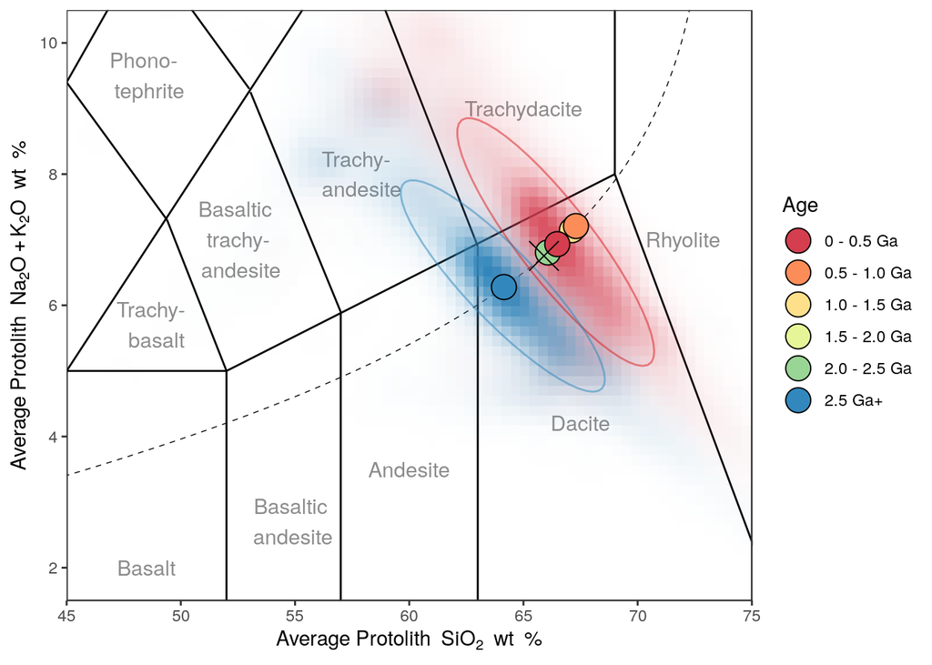

```r
crust_compare_df <- rbind(archean_crust,early_prot_crust,paleo_prot_crust,meso_prot_crust,neo_prot_crust,modern_crust)


crust_compare_df$age <- rev(c("0 - 0.5 Ga","0.5 - 1.0 Ga","1.0 - 1.5 Ga","1.5 - 2.0 Ga","2.0 - 2.5 Ga","2.5 Ga+"))
crust_compare_df$age <- factor(crust_compare_df$age , levels = rev(crust_compare_df$age))

psi_trend<-do.call(rbind,lapply(seq(-3,3,0.1),function(x) coefficients_to_comp(pristine_omega,x)))
psi_trend_coarse<-do.call(rbind,lapply(seq(-2,3,0.5),function(x) coefficients_to_comp(pristine_omega,x)))

tas+ geom_path(data=psi_trend,aes(x=SiO2*100,y=(Na2O+K2O)*100),linetype="dashed",size=0.25) +
  stat_density2d(data=cbined_uncert,geom="tile", aes(fill = group, alpha=..density..,x=SiO2*100,y=(Na2O+K2O)*100),
                 contour=FALSE,show.legend = F) + scale_alpha(range=c(0,1)) +
  stat_ellipse(data=modern_crust_uncert_ig_cent, aes(x=SiO2*100,y=(Na2O+K2O)*100),
               colour="#d7191c",level = 0.683,alpha=0.5,show.legend = F) +
  stat_ellipse(data=arch_crust_uncert_ig_cent, aes(x=SiO2*100,y=(Na2O+K2O)*100),
               colour="#2b83ba",level = 0.683,alpha=0.5,show.legend = F) +
  geom_point(data=crust_compare_df,aes(x=SiO2*100,y=(Na2O+K2O)*100,fill=age),colour="black",pch=21,size=6) +
  scale_fill_brewer(palette="Spectral") + labs(fill="Age") +
  geom_point(data=rudnick_gao_ucc,aes(x=SiO2*100,y=100*(Na2O+K2O)),colour="black",pch=4,size=7,show.legend = F) +
  coord_cartesian(xlim=c(45,75),ylim=c(1.5,10.5)) + guides(color=guide_legend(override.aes=list(fill=NA)))
```

Thus, we conclude that prior to 2.5 Ga, the crust was *on average* dacitic and slightly more mafic than the present day, but by 2.0 Ga had evolved into its mostly present day more evolved composition (indicated by the cross).

## Secular Trends in Protolith Composition

Another way of looking at the variation in compositions through time is to look at the mean $\psi$, before mixing the compositions. This can’t be used to reconstruct crustal composition but it is useful in looking at changes in protolith diversity through time. We also extract the standard deviations for each time interval.

```r
modern_psi_geo <- mean(modern$psi,na.rm=T)
neo_prot_psi_geo <- mean(neo_prot$psi,na.rm=T) # geometric mean. i.e. mean _without_ mixing
meso_prot_psi_geo <- mean(meso_prot$psi,na.rm=T)
paleo_prot_psi_geo <- mean(paleo_prot$psi,na.rm=T)
early_prot_psi_geo <- mean(early_prot$psi,na.rm=T)
archean_psi_geo <- mean(archean$psi,na.rm=T)
paleo_archean_psi_geo <- mean(paleo_archean$psi,na.rm=T)
neo_archean_psi_geo <- mean(neo_archean$psi,na.rm=T)
hadean_psi_geo <-  mean(hadean$psi,na.rm=T)

modern_psi_sd <- sd(modern$psi,na.rm=T)
neo_prot_psi_sd <- sd(neo_prot$psi,na.rm=T)
meso_prot_psi_sd <- sd(meso_prot$psi,na.rm=T)
paleo_prot_psi_sd <- sd(paleo_prot$psi,na.rm=T)
early_prot_psi_sd <- sd(early_prot$psi,na.rm=T)
archean_psi_sd <- sd(archean$psi,na.rm=T)
paleo_archean_psi_sd <- sd(paleo_archean$psi,na.rm=T)
neo_archean_psi_sd <- sd(neo_archean$psi,na.rm=T)
hadean_psi_sd <-  sd(hadean$psi,na.rm=T)
```

Now we visualise how these mean $\psi$ values have changed in time.

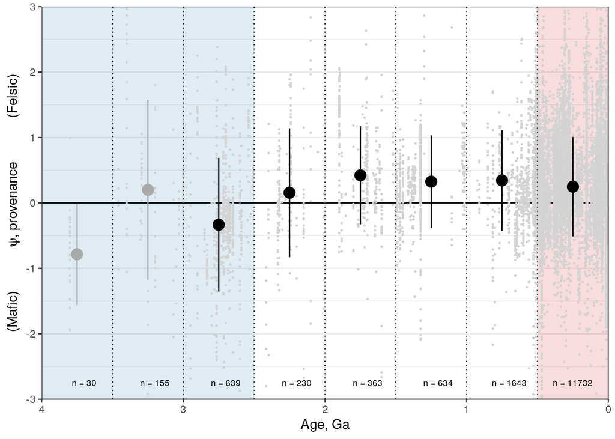

```r
recombined_data$chunked_age_500 <- as.factor((recombined_data$interpreted_age%/%500)*500)
chunk_to_n_500 <- function(chunk){
  sum(recombined_data[!(is.na(recombined_data$interpreted_age)),]$chunked_age_500 == chunk)
}
ns <- paste0("n = ",as.character(sapply(as.factor(seq(0,3500,500)),chunk_to_n_500)))

means_df <- data.frame(psi=c(modern_psi_geo,neo_prot_psi_geo,meso_prot_psi_geo,paleo_prot_psi_geo,early_prot_psi_geo,paleo_archean_psi_geo,
                             neo_archean_psi_geo,hadean_psi_geo),
                       age=c(0.25,0.75,1.25,1.75,2.25,2.75,3.25,3.75),
                       sd=c(modern_psi_sd,neo_prot_psi_sd,meso_prot_psi_sd,paleo_prot_psi_sd,early_prot_psi_sd,paleo_archean_psi_sd,
                            neo_archean_psi_sd,hadean_psi_sd))

ggplot() +
  geom_polygon(aes(x=c(0,0,0.5,0.5),y=c(-3,3,3,-3)),fill="#d7191c",alpha=0.15) +
  geom_polygon(aes(x=c(2.5,2.5,4,4),y=c(-3,3,3,-3)),fill="#2b83ba",alpha=0.15) +
  geom_hline(yintercept=0,colour="black") +
  geom_point(data=recombined_data,aes(x=interpreted_age/1000,y=psi),size=0.3,colour="lightgrey") +
  theme_bw() + coord_cartesian(ylim=c(-3,3),expand=c(0,0)) +
  ylab(expression("(Mafic)            "*psi*", provenance            (Felsic)")) + xlab("Age, Ga") +
  geom_errorbar(data=means_df[1:6,],aes(x=age,y=psi,ymin=psi-sd,ymax=psi+sd),width=0) + geom_point(data=means_df[1:6,],aes(x=age,y=psi),size=4) +
  geom_vline(data=data.frame(x=c(0.5,1,1.5,2,2.5,3,3.5)),size=0.4,linetype="dotted",aes(xintercept=x)) +
  geom_text(data=data.frame(x=c(0.25,0.7,1.2,1.7,2.2,2.7,3.2,3.7),y=-2.75,label=ns),aes(x=x,y=y,label=label),size=2.5) +
  scale_x_reverse() +
  geom_errorbar(data=means_df[7:8,],aes(x=age,y=psi,ymin=psi-sd,ymax=psi+sd),width=0,colour="darkgrey") +
  geom_point(data=means_df[7:8,],aes(x=age,y=psi),size=4,colour="darkgrey")
```

It is interesting to note that there is significant scatter arond the secular trend of increasingly more felsic crust. Whilst there certainly is a meaningful difference between the two populations this difference can be overstated. The boxplots show that the two populations overlap significantly.

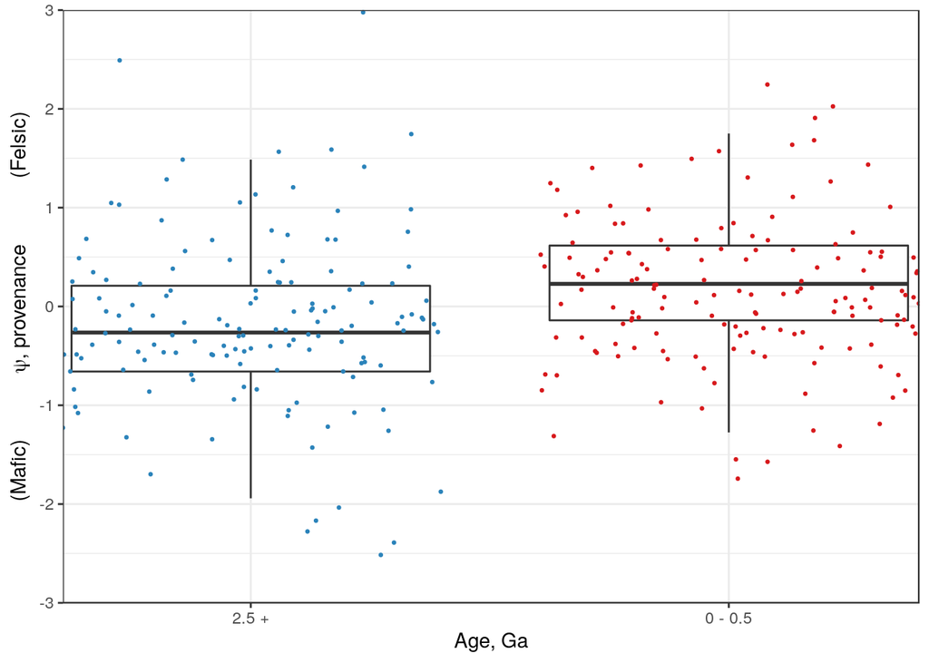

```r
modern_psi_vals <- modern$psi[!is.na(modern$psi)]
archean_psi_vals <- archean$psi[!is.na(archean$psi)]

psi_df<- rbind(data.frame(psi = modern_psi_vals,age="0 - 0.5"),
          data.frame(psi = archean_psi_vals,age="2.5 +"))

psi_df$age <- factor(psi_df$age,levels=c("2.5 +","0 - 0.5"))

ggplot(psi_df,aes(x=age,y=psi)) + geom_boxplot(outlier.shape = NA) + theme_bw() +
  geom_jitter(data=sample_n(data.frame(psi = modern_psi_vals,age="0 - 0.5"),150),aes(x=age,y=psi,colour=age),size=0.5) +
  geom_jitter(data=sample_n(data.frame(psi = archean_psi_vals,age="2.5 +"),150),aes(x=age,y=psi,colour=age),size=0.5) +
  labs("Age") + labs(colour="Age") + xlab("Age, Ga") +
  ylab(expression("(Mafic)            "*psi*", provenance            (Felsic)")) + xlab("Age, Ga") +
  scale_color_manual(values=c("#d7191c","#2b83ba")) + guides(colour=F) + coord_cartesian(ylim=c(-3,3),expand=c(0,0))
```

# Weathering Results

## Long term changes in CO2 sequestration potential

A useful benefit of our model is that we can calculate how much CO2 has been lost per unit rock initially eroded. Here we define a few functions to explore how weathering affects mass loss.

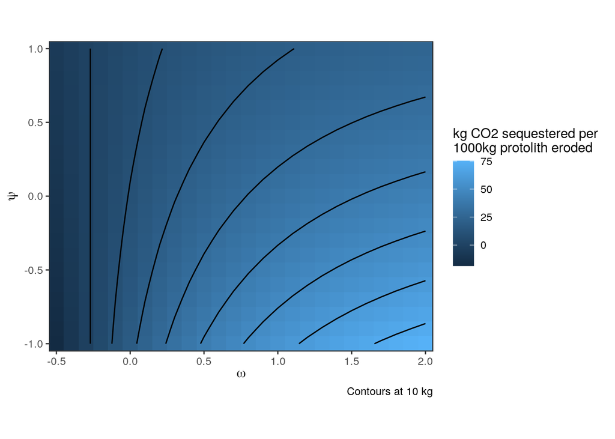

```r
frac_mass_loss <- function(omega,psi){
  final_comp <- coefficients_to_comp(omega,psi)
  initial_comp <- coefficients_to_comp(pristine_omega,psi)
  fractional_mass_lost <- (final_comp/initial_comp)*(initial_comp$Al2O3/final_comp$Al2O3) -1
  return(fractional_mass_lost)
}


abs_mass_loss <- function(omega,psi){
  # Returns kg of each element lost per kg of original rock
  abs_mass_loss_ox <- frac_mass_loss(omega,psi)*coefficients_to_comp(pristine_omega,psi)
  abs_mass_loss_elem <- abs_mass_loss_ox  / c(2.1392,1.8895,1.4297,1.6582,1.3480,1.3992,1.2046) # oxide to elemental
  return(abs_mass_loss_elem)
}

co2_drawdown_potential <- function(omega,psi){
  # Returns kg of CO2 potentially removed per kg of original rock
  # Assumes all acidity donated by carbonix acid
  # Ca all sunk as carbonate and Mg exchanged for Ca at ocean vents
  mass_loss <- abs_mass_loss(omega,psi)
  moles_ca_eroded <- 1000*mass_loss$CaO/40.078 # *10^3 to convert kg -> g
  moles_mg_eroded <- 1000*mass_loss$MgO/24.305
  moles_co2_seq <- -1*(moles_ca_eroded + moles_mg_eroded)
  mass_co2_seq <- (moles_co2_seq*44)/1000 # kg CO2
  return(mass_co2_seq)
}

grid_omega_psi <- expand.grid(seq(-0.5,2,0.1),seq(-1,1,0.1))
names(grid_omega_psi) <- c("omega","psi")

co2_loss_df <- do.call(rbind,lapply(seq(1,nrow(grid_omega_psi)),
                     function(x) co2_drawdown_potential(grid_omega_psi[x,1],
                                                grid_omega_psi[x,2])))

ggplot(cbind(grid_omega_psi,co2_loss_df),aes(x=omega,y=psi,fill=co2_loss_df*1000)) + geom_tile() +
  coord_equal() + theme_bw() + scale_x_continuous(expand=c(0,0)) +
  scale_y_continuous(expand=c(0,0)) + stat_contour(aes(z=co2_loss_df*1000),colour="black",breaks=seq(0,150,10)) +
  xlab(expression(omega)) + ylab(expression(psi)) + labs(fill="kg CO2 sequestered per \n1000kg protolith eroded",caption="Contours at 10 kg")
```

Now we create some profiles for typical protoliths to look at how much CO2 is sequestered for a given weathering intensity.

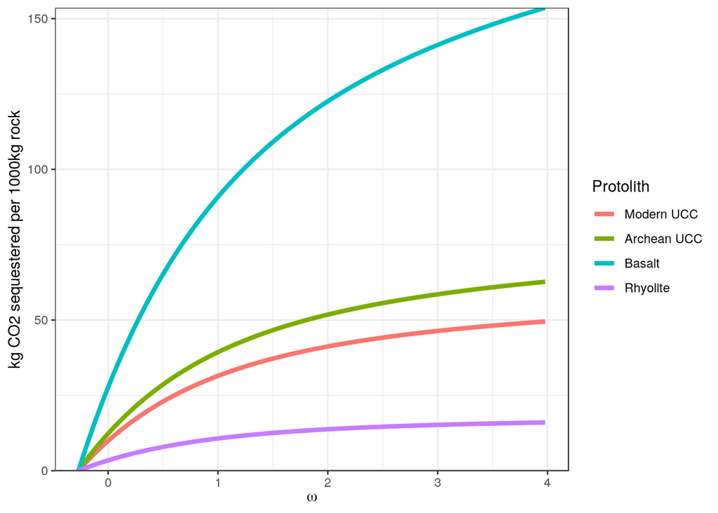

```r
UCC_weath_co2 <- sapply(seq(pristine_omega,4,0.05),function(x) co2_drawdown_potential(x,modern_psi))
arch_UCC_weath_co2 <- sapply(seq(pristine_omega,4,0.05),function(x) co2_drawdown_potential(x,archean_psi))
basalt_weath_co2 <- sapply(seq(pristine_omega,4,0.05),function(x) co2_drawdown_potential(x,-2))
rhyolite_weath_co2 <- sapply(seq(pristine_omega,4,0.05),function(x) co2_drawdown_potential(x,2))

co2_df <- data.frame(omega=(seq(pristine_omega,4,0.05)),modern_co2 = UCC_weath_co2,
                     arch_co2 = arch_UCC_weath_co2,basalt_co2 = basalt_weath_co2,
                     rhyolite_weath_co2)
ggplot(melt(co2_df,id.vars = "omega"),aes(x=omega,colour=variable,y=value*1000)) + geom_path(size=1.5) + theme_bw() + xlab(expression(omega)) +
  ylab("kg CO2 sequestered per 1000kg rock") + scale_y_continuous(expand=c(0,0)) + labs(colour="Protolith") +
  scale_color_discrete(labels=c("Modern UCC","Archean UCC","Basalt","Rhyolite"))
```

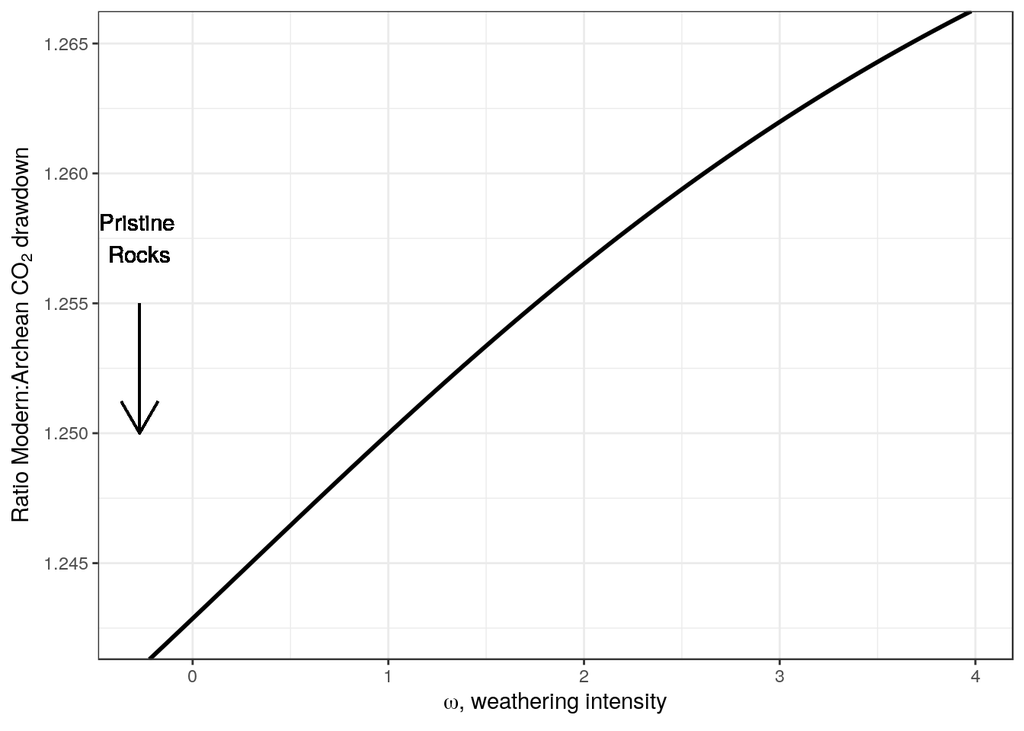

```r
ggplot(co2_df,aes(x=omega,y=arch_co2/modern_co2)) + geom_path() + geom_path(size=1) +
  theme_bw() + xlab(expression(omega*", weathering intensity"))  + scale_y_continuous(expand=c(0,0)) +
  ylab(expression("Ratio Modern:Archean "*CO[2]*" drawdown")) +
  geom_segment(aes(x=pristine_omega,xend=pristine_omega,y=1.255,yend=1.25),arrow = arrow()) +
  geom_text(aes(y=1.2575,x=pristine_omega,label="Pristine \nRocks"))
```

Now we visualise crustal compositions through time on an $\omega$-$\psi$ plot alongside contours of CO2 drawdown capacity.

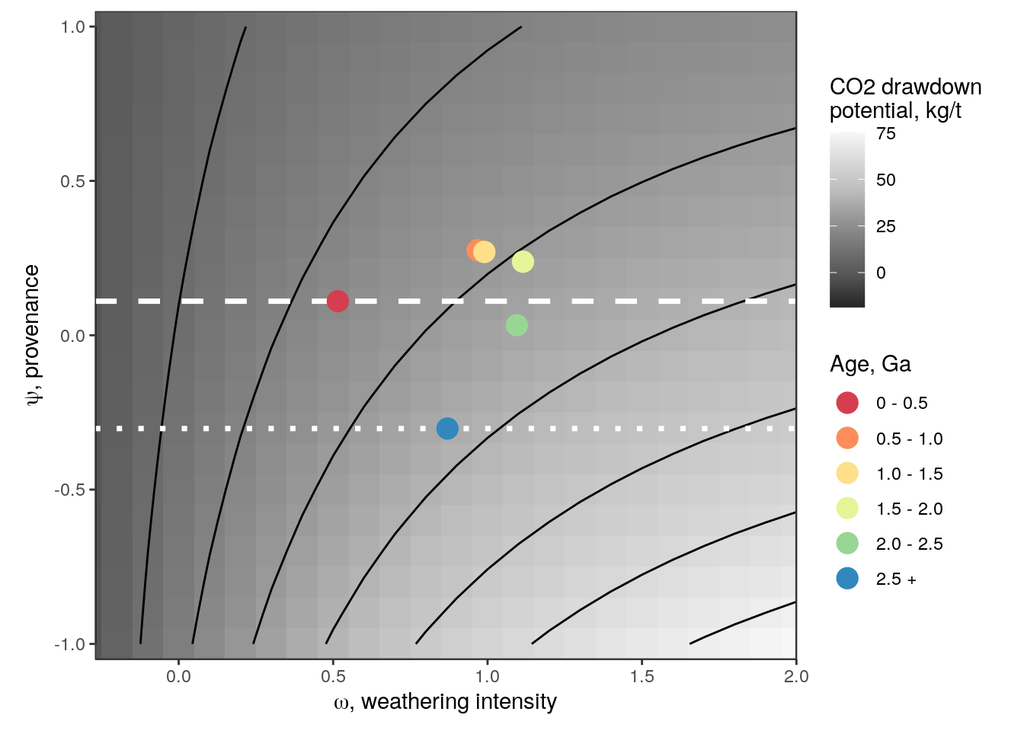

```r
mixture_coeffs$origin <- factor(mixture_coeffs$origin,levels=c("modern","neo_prot","paleo_prot","meso_prot","early_prot","archean","river_average"))

ggplot(cbind(grid_omega_psi,co2_loss_df),aes(x=omega,y=psi,fill=co2_loss_df*1000)) + geom_tile() +
  coord_equal(xlim=c(pristine_omega,2)) + scale_fill_distiller(palette=6) + theme_bw() + scale_x_continuous(expand=c(0,0)) +
  scale_y_continuous(expand=c(0,0)) + stat_contour(aes(z=co2_loss_df*1000),colour="black",breaks=seq(0,150,10)) +
  xlab(expression(omega*", weathering intensity")) + ylab(expression(psi*", provenance")) + labs(fill="CO2 drawdown \npotential, kg/t")  +
  geom_hline(yintercept = modern_psi,colour="white",linetype="dashed",size=1.25) +
  geom_hline(yintercept = archean_psi,colour="white",linetype="dotted",size=1.25) +
  geom_point(inherit.aes=F,data=mixture_coeffs[1:6,],aes(x=omega,y=psi,colour=origin),size=4.5) +
  scale_colour_brewer(palette ="Spectral",labels=c("0 - 0.5","0.5 - 1.0","1.0 - 1.5","1.5 - 2.0","2.0 - 2.5","2.5 +")) +
  labs(colour="Age, Ga")
```

```r
co2_loss_df_samples <- data.frame(do.call(rbind,lapply(seq(1,nrow(mixture_coeffs)),
                     function(x) co2_drawdown_potential(mixture_coeffs[x,"omega"],
                                                mixture_coeffs[x,"psi"]))))*1000
names(co2_loss_df_samples) <- c("CO2 drawdown")
```

## Phanerozoic history of weathering intensity

On shorter timescales however, we may expect to see secular variations in weathering intensity in response to cooling (e.g. [Pogge von Strandmann et al 2017](https://www.geochemicalperspectivesletters.org/article1726/)). To overcome the local signal preserved in individual sediments we need high data density. In addition we need to smooth the highly noisy signal, hence we use a Gaussian window smoothing kernel with a 30 Myr bandwidth. We use [Will Gearty’s `deeptime` package](https://github.com/willgearty/deeptime) here to add a geological timescale to the figure.

```r
recombined_data_young <- recombined_data[!(is.na(recombined_data$interpreted_age)) & recombined_data$interpreted_age<600,]
recombined_data_young <- recombined_data_young[order(recombined_data_young$interpreted_age),]

# Apply a gaussian filter with bandwidth of 30 Myr.
smoothed_weathering <- data.frame(ksmooth(x=recombined_data_young$interpreted_age,y=recombined_data_young$omega,kernel="normal",bandwidth = 30,n=1000))
```

To generate uncertainties for our smoothed trend we use a bootstrap resampling technique.

```r
combined_bootstrap_smooths <- data.frame(x = smoothed_weathering$x)

n_bootstrap = 1000
# Warning this loop can be slow! Change `n_bootstrap` to a smaller number for faster runtime
for(i in 1:n_bootstrap){
  bootstrap_resample <- recombined_data_young[sample(1:nrow(recombined_data_young),nrow(recombined_data_young),replace=TRUE),]
  bootstrap_resample <- bootstrap_resample[order(bootstrap_resample$interpreted_age),]
  smoothed_bootstrap <- data.frame(ksmooth(x=bootstrap_resample$interpreted_age,y=bootstrap_resample$omega,kernel="normal",
                                           range.x=range(recombined_data_young$interpreted_age),bandwidth = 30,n=1000))
  combined_bootstrap_smooths <- cbind(combined_bootstrap_smooths,smoothed_bootstrap$y)
}

bootstrap_mean <- apply(combined_bootstrap_smooths[,1:n_bootstrap+1],1,mean)
bootstrap_sd <- apply(combined_bootstrap_smooths[,1:n_bootstrap+1],1,sd)
bootstrap_upper <- apply(combined_bootstrap_smooths[,1:n_bootstrap+1],1,function(x) quantile(unlist(x),1 )) # change 1 for 0.95 for 95% envelope etc...
bootstrap_lower <- apply(combined_bootstrap_smooths[,1:n_bootstrap+1],1,function(x) quantile(unlist(x),0 ))
bootstrap_results <- data.frame(x = combined_bootstrap_smooths$x,mean=bootstrap_mean,sd=bootstrap_sd,min=bootstrap_lower,max=bootstrap_upper)
```

Finally we visualise the trend including the bootstrap uncertainties. This smoothed time series is written out as an individual file.

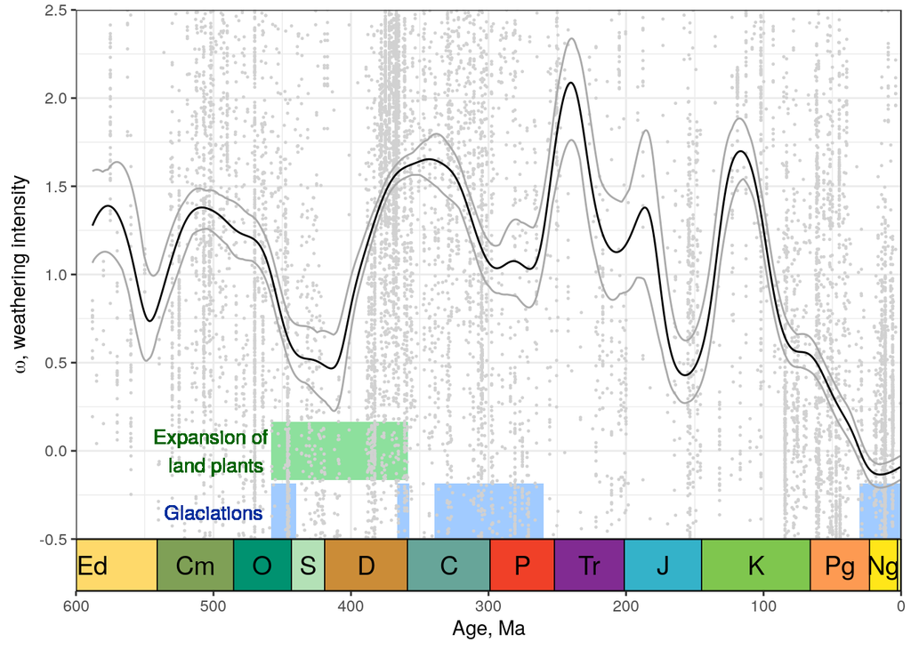

```r
# Plot up the data and the smoothed results
ggplot(recombined_data_young, aes(x=interpreted_age,y=omega)) +
  geom_segment(inherit.aes=F, aes(x=0,xend=30,y=-0.35,yend=-0.35),colour="#a1cbff",size=15) + # Dates from MacDonald et al 2019
  geom_segment(inherit.aes=F, aes(x=0,xend=30,y=-0.35,yend=-0.35),colour="#a1cbff",size=15) +
  geom_segment(inherit.aes=F, aes(x=260,xend=339,y=-0.35,yend=-0.35),colour="#a1cbff",size=15) +
  geom_segment(inherit.aes=F, aes(x=358,xend=366,y=-0.35,yend=-0.35),colour="#a1cbff",size=15) +
  geom_segment(inherit.aes=F, aes(x=440,xend=458,y=-0.35,yend=-0.35),colour="#a1cbff",size=15)  +
  geom_segment(inherit.aes=F,aes(xend=458,x=359,y=0,yend=0),colour="#8de09d",size=15) + # Dates from McMahon & Davies 2018, upsurge in mudrock
  geom_point(size=0.2,colour="#d1d1d1") + theme_bw() +
  ylab(expression(omega*", weathering intensity")) + xlab("Age, Ma") +
  scale_x_reverse()  +
  geom_path(data=smoothed_weathering,aes(x=x,y=y),colour="black") +
  geom_path(data=bootstrap_results,aes(x=x,y=min),colour="darkgrey") +
  geom_path(data=bootstrap_results,aes(x=x,y=max),colour="darkgrey") +
  coord_geo(xlim = c(600, 0), ylim=c(-0.5,2.5),expand=c(0,0))  +
  geom_text(aes(x=500,y=0,label="Expansion of \n land plants"),colour="darkgreen") +
  geom_text(aes(x=500,y=-0.35,label="Glaciations"),colour="#002f9c")
```

### Writing weathering data outfiles

We write the smoothed weathering series and the $\omega$, $\psi$ data with ages and other metadata to file so that they can be easily accessed.

```r
omega_psi_metadata.csv <- data.frame(age_ma = recombined_data$interpreted_age,omega_weathering =recombined_data$omega,psi_provenance = recombined_data$psi,sample_id = recombined_data$sample_id, strat_name = recombined_data$strat_name_long)
write.csv(omega_psi_metadata.csv,"data/omega_psi_metadata.csv",row.names = F)

weathering_time_series_out <-data.frame(age_Ma=smoothed_weathering$x,omega=smoothed_weathering$y,bootstrap_upper_bnd=bootstrap_results$max,bootstrap_lower_bnd=bootstrap_results$min)

write.csv(weathering_time_series_out,"data/weathering_time_series.csv",row.names = F)
```

### Stratigraphic Unit Averages

Here we generate an analagous figure to above but first we take the average of all the $\omega$ values from within a stratigraphic unit. This will potentially limit the effect of sampling bias.

First we calculate the mean ω value for each stratigraphic unit (indicated by the strat_name_long field in the SGP database). To give each unit an age we simply take the mean of all the different ages assigned to that unit in the SGP dataset. Next we smooth this data using a gaussian average as normal.

```r
formation_average_omega <- aggregate(recombined_data_young$omega,by=list(recombined_data_young$strat_name_long),mean)
names(formation_average_omega) <- c("strat_name_long","omega")
formation_average_omega$interpreted_age <- aggregate(recombined_data_young$interpreted_age,by=list(recombined_data_young$strat_name_long),function(x) mean(x,na.rm=F))$x

formation_average_omega <- formation_average_omega[order(formation_average_omega$interpreted_age),]
formation_average_omega <- formation_average_omega[!is.na(formation_average_omega$interpreted_age),]

smoothed_weathering_om_avg <- data.frame(ksmooth(x=formation_average_omega$interpreted_age,y=formation_average_omega$omega,kernel="normal",bandwidth = 30, n=1000))
```

Similarly, for these formation averaged samples we bootstrap the data in the same way as above.

```r
combined_bootstrap_smooths_avg <- data.frame(x = smoothed_weathering_om_avg$x)

n_bootstrap = 1000

for(i in 1:n_bootstrap){
  bootstrap_resample_avg <- formation_average_omega[sample(1:nrow(formation_average_omega),nrow(formation_average_omega),replace=TRUE),]
  bootstrap_resample_avg <- bootstrap_resample_avg[order(bootstrap_resample_avg$interpreted_age),]
  smoothed_bootstrap_avg <- data.frame(ksmooth(x=bootstrap_resample_avg$interpreted_age,y=bootstrap_resample_avg$omega,kernel="normal",
                                           range.x=range(formation_average_omega$interpreted_age),bandwidth = 30,n=1000))
  combined_bootstrap_smooths_avg <- cbind(combined_bootstrap_smooths_avg,smoothed_bootstrap_avg$y)
}

bootstrap_mean_avg <- apply(combined_bootstrap_smooths_avg[,1:n_bootstrap+1],1,mean)
bootstrap_sd_avg <- apply(combined_bootstrap_smooths_avg[,1:n_bootstrap+1],1,sd)
bootstrap_lower_avg <- apply(combined_bootstrap_smooths_avg[,1:n_bootstrap+1],1,function(x) range(x)[1])
bootstrap_upper_avg <- apply(combined_bootstrap_smooths_avg[,1:n_bootstrap+1],1,function(x) range(x)[2])
bootstrap_results_avg <- data.frame(x = combined_bootstrap_smooths_avg$x,mean=bootstrap_mean_avg,sd=bootstrap_sd_avg,min=bootstrap_lower_avg,max=bootstrap_upper_avg)
```

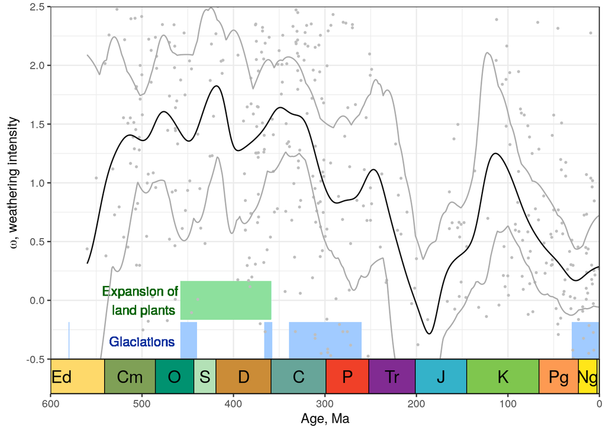

```r
ggplot(formation_average_omega, aes(x=interpreted_age,y=omega)) +
  geom_segment(inherit.aes=F, aes(x=0,xend=30,y=-0.35,yend=-0.35),colour="#a1cbff",size=15) + # Dates from MacDonald et al 2019
  geom_segment(inherit.aes=F, aes(x=0,xend=30,y=-0.35,yend=-0.35),colour="#a1cbff",size=15) +
  geom_segment(inherit.aes=F, aes(x=260,xend=339,y=-0.35,yend=-0.35),colour="#a1cbff",size=15) +
  geom_segment(inherit.aes=F, aes(x=358,xend=366,y=-0.35,yend=-0.35),colour="#a1cbff",size=15) +
  geom_segment(inherit.aes=F, aes(x=440,xend=458,y=-0.35,yend=-0.35),colour="#a1cbff",size=15)  +
  geom_segment(inherit.aes=F, aes(x=579.63,xend=579.88,y=-0.35,yend=-0.35),colour="#a1cbff",size=15)  +
  geom_segment(inherit.aes=F,aes(xend=458,x=359,y=0,yend=0),colour="#8de09d",size=15) + # Dates from McMahon & Davies 2018, upsurge in mudrock
  geom_point(size=0.5,colour="grey") + theme_bw() +
  ylab(expression(omega*", weathering intensity")) + xlab("Age, Ma") +
  scale_x_reverse()  +
  #coord_cartesian(xlim = c(600, 0), ylim=c(-0.5,2.5),expand=c(0,0)) +
  coord_geo(xlim = c(600, 0), ylim=c(-0.5,2.5),expand=c(0,0))  +
  geom_text(aes(x=500,y=0,label="Expansion of \n land plants"),colour="darkgreen") +
  geom_text(aes(x=500,y=-0.35,label="Glaciations"),colour="#002f9c") +
  geom_path(data=bootstrap_results_avg,aes(x=x,y=min),colour="darkgrey") +
  geom_path(data=bootstrap_results_avg,aes(x=x,y=max),colour="darkgrey") +
  geom_path(data=smoothed_weathering_om_avg,aes(x=x,y=y),colour="black")
```